# Rowvember

Joseph V. Casillas

2018-12-02 17:24:26

# 1 Analyses and plots

Each year in November we do a series of time trials in which we have to row for maximum distance in a set amount of time. The first week starts at 2 minutes and the time is increased by 1 minute each week. For every time interval, each rower must complete 4 trials. This is the data from my rowvember’s from 2016 through 2018.

## 1.1 Total meters for Rowvember by year

Over the course of the month we complete 16 rows, so the meters really add up. Let’s take a look at how much rowing actually goes down.

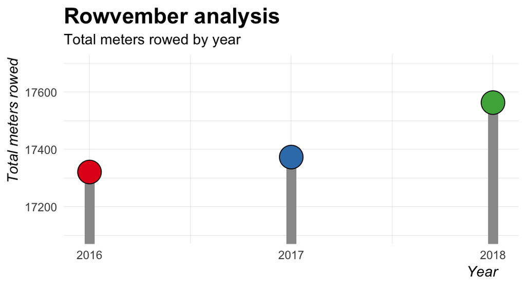

| year | Totals meters | Totals miles |
| --- | --- | --- |
| 2016 | 17321 | 10.76 |
| 2017 | 17373 | 10.8 |
| 2018 | 17563 | 10.91 |
| total | 52257 | 32.47 |

In the last 3 years I have rowed a total of 52257 meters! That’s 32.47 miles! One thing I was interested in was finding out if I was doing more work (rowing more distance) each year. Looking at the plot I see that I did indeed row more meters each year (the height of the colored dots increases). We can visualize the year to year improvement by subtracting the total meters of a given year from those of the previous year.

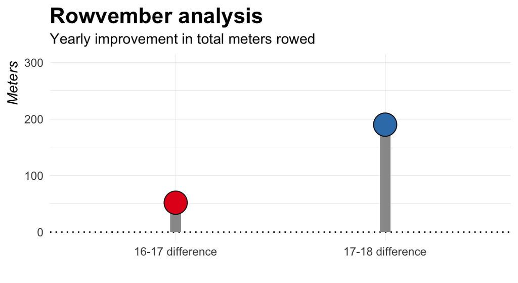

| Year | Improvement |
| --- | --- |
| 16-17 | 52 |
| 17-18 | 190 |

This plot shows the difference in meters of total output from 2016 to 2017 and from 2017 to 2018. I’ve rowed more total meters every year. Specifically, I improved by 52 total meters from 2016 to 2017, and by 190(!) total meters from 2017 to 2018. Nice.

## 1.2 Total meters per time interval

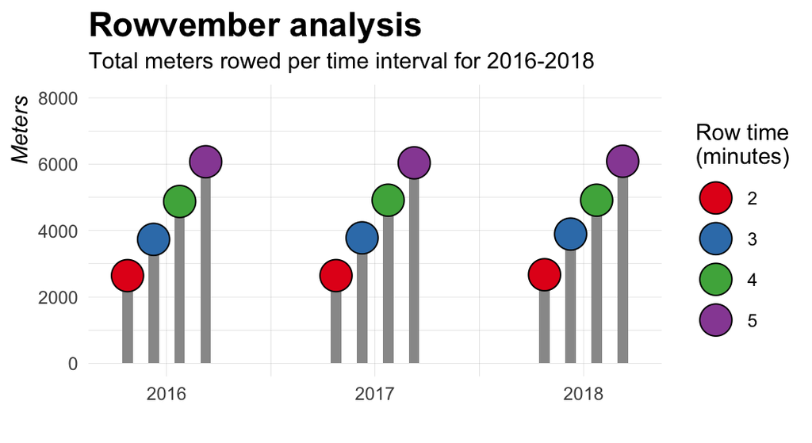

| Row time | Year 2016 | Year 2017 | Year 2018 |
| --- | --- | --- | --- |
| 2 | 2641 | 2642 | 2669 |
| 3 | 3733 | 3779 | 3893 |
| 4 | 4875 | 4914 | 4914 |
| 5 | 6072 | 6038 | 6087 |

It’s pretty clear that with each additional minute of row time the total distance increases (big surprise). What may be more interesting is seeing the difference in total meters rowed per time interval for each year, so, again, we can subtract the total distance rowed from that of the previous year, for each time interval.

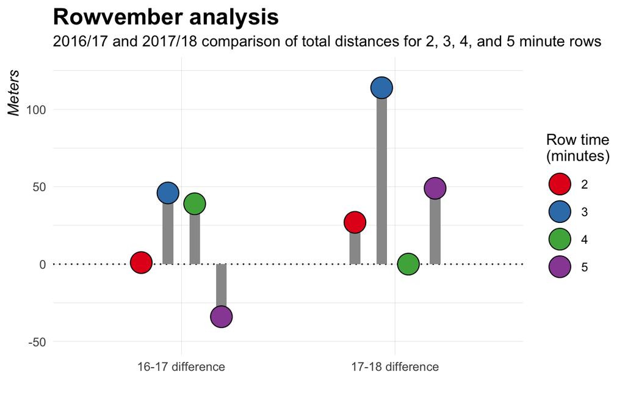

| Row time | Comparison 16-17 | Comparison 17-18 |
| --- | --- | --- |
| 2 | 1 | 27 |
| 3 | 46 | 114 |
| 4 | 39 | 0 |
| 5 | -34 | 49 |

## 1.3 Average meters per time interval

```r
df_individual %>%
    group_by(., rower, time) %>%
    summarize(., avg_distance = mean(distance), sd_distance = sd(distance)) %>%
    mutate_if(., is.numeric, round, digits = 2) %>%
    datatable(.)
```

|  | rower | time | avg_distance | sd_distance |
| --- | --- | --- | --- | --- |
| 1 | joseph | 2 | 662.67 | 9.45 |
| 2 | joseph | 3 | 950.42 | 18.63 |
| 3 | joseph | 4 | 1225.25 | 10.32 |
| 4 | joseph | 5 | 1516.42 | 14.91 |

## 1.4 Fit model of meters as a function of time

```
## Linear mixed model fit by maximum likelihood . t-tests use
##   Satterthwaite's method [lmerModLmerTest]
## Formula: distance ~ (ot1 + ot2) + year + ((ot1 + ot2) | trial) + ((ot1 +
##     ot2) | year)
##    Data: df_individual
##
##      AIC      BIC   logLik deviance df.resid
##    407.1    438.9   -186.6    373.1       31
##
## Scaled residuals:
##      Min       1Q   Median       3Q      Max
## -2.26931 -0.45164 -0.05624  0.40871  2.73903
##
## Random effects:
##  Groups   Name        Variance Std.Dev. Corr
##  trial    (Intercept)   0.000   0.000
##           ot1          46.364   6.809    NaN
##           ot2           4.733   2.175    NaN 1.00
##  year     (Intercept)   0.000   0.000
##           ot1          11.172   3.342    NaN
##           ot2          44.373   6.661    NaN 1.00
##  Residual             122.423  11.064
## Number of obs: 48, groups:  trial, 4; year, 3
##
## Fixed effects:
##               Estimate Std. Error         df t value Pr(>|t|)
## (Intercept) -14164.875   3945.133     40.916  -3.590 0.000876 ***
## ot1            634.168      5.051      4.136 125.542 1.45e-08 ***
## ot2              1.708      5.116      3.229   0.334 0.758976
## year             7.563      1.956     40.916   3.866 0.000388 ***
## ---
## Signif. codes:  0 '***' 0.001 '**' 0.01 '*' 0.05 '.' 0.1 ' ' 1
##
## Correlation of Fixed Effects:
##      (Intr) ot1    ot2
## ot1   0.000
## ot2   0.000  0.430
## year -1.000  0.000  0.000
## convergence code: 0
## unable to evaluate scaled gradient
## Model failed to converge: degenerate  Hessian with 2 negative eigenvalues
```

## 1.5 Plots of meters as a function of time

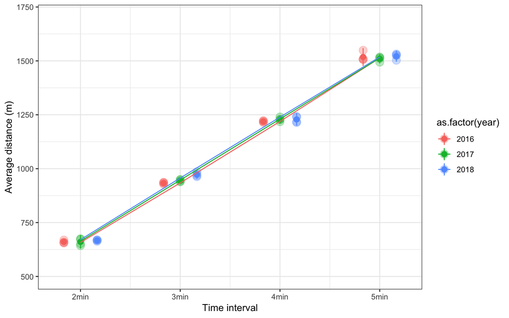

```r
# Plot avg distance for each time
df_individual %>%
  ggplot(., aes(x = time, y = distance, color = as.factor(year), dodge = year)) +
  geom_point(position = position_dodge(0.5), size = 4, alpha = 0.3) +
  stat_summary(fun.data = mean_sdl, geom = 'pointrange',
                         position = position_dodge(0.5)) +
  stat_summary(fun.y = mean, geom = 'point', size = 2,
                         position = position_dodge(0.5)) +
  stat_summary(aes(y = fitted(fit)), fun.y = mean, geom = 'line') +
  scale_x_continuous(breaks = c(2, 3, 4, 5),
                     labels = c('2min', '3min', '4min', '5min')) +
    ylim(500, 1700) +
  xlab('Time interval') + ylab('Average distance (m)') +
  theme_bw()
```

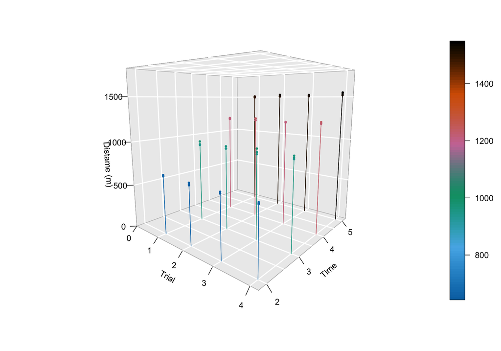

```r
# 3D plot
with(df_individual, scatter3D(x = trial, y = time, z = distance,
     colvar = distance, pch = 19, cex = 0.5, phi = 10, bty = 'g',
     type = 'h', ticktype = "detailed", xlab = 'Trial', ylab = 'Time',
     zlab = 'Distame (m)', zlim = c(0, 1800), xlim = c(0, 4.2),
     ylim = c(1.8, 5.2), col = gg.col(100)))
```

# 2 Group data

### 2.0.1 Total meters (females)

|  | athlete | group | totalM |
| --- | --- | --- | --- |
| 1 | Greta Schneider | female | 15665 |
| 2 | Amanda Green | female | 15509 |
| 3 | Mo Rabbitt | female | 14741 |
| 4 | Jackie Szabo | female | 14285 |
| 5 | Cris Rampolla | female | 14160 |
| 6 | Amanda Lehmkuhl | female | 13107 |
| 7 | Donna Borst | female | 12306 |
| 8 | Lisa Walsh | female | 10637 |
| 9 | Tara Arhakos | female | 6581 |
| 10 | Alexandra Walczak | female | 6237 |

[output cut: 12 more lines]

### 2.0.2 Total meters (males)

|  | athlete | group | totalM |
| --- | --- | --- | --- |
| 1 | Joseph Casillas | male | 17321 |
| 2 | Keith Sanchez | male | 16461 |
| 3 | Afam Moneme | male | 16017 |
| 4 | Michael Bernardi | male | 15999 |
| 5 | Joseph Percy | male | 12952 |
| 6 | Adolf Soos | male | 12035 |
| 7 | Matt Corrado | male | 8815 |
| 8 | Ken Percy | male | 8814 |
| 9 | Steve Rampolla | male | 8095 |
| 10 | Bill Reeder | male | 7474 |

[output cut: 20 more lines]

### 2.0.3 Total meters as a function of time

```
## group: female
## time: 2
## # A tibble: 10 x 4
## # Groups:   athlete, group [10]
##    athlete         group   time totalM
##    <fct>           <fct>  <dbl>  <dbl>
##  1 Greta Schneider female     2   2380
##  2 Amanda Green    female     2   2326
##  3 Mo Rabbitt      female     2   2180
##  4 Cris Rampolla   female     2   2130
##  5 Donna Borst     female     2   2101
##  6 Jackie Szabo    female     2   2098
##  7 Amanda Lehmkuhl female     2   1533
##  8 Alyssa Calvosa  female     2   1021
##  9 Sindy Rodriguez female     2    989
## 10 Sunita Algoo    female     2    987
## --------------------------------------------------------
## group: male
## time: 2
## # A tibble: 10 x 4
## # Groups:   athlete, group [10]
##    athlete           group  time totalM
##    <fct>             <fct> <dbl>  <dbl>
##  1 Joseph Casillas   male      2   2641
##  2 Keith Sanchez     male      2   2556
##  3 Hamilton Villamor male      2   1933
##  4 Afam Moneme       male      2   1923
##  5 Michael Bernardi  male      2   1885
##  6 Ken Percy         male      2   1870
##  7 Don Borst         male      2   1851
##  8 Rhaman Johnson    male      2   1245
##  9 Adolf Soos        male      2   1243
## 10 Ashe Husein       male      2   1242
## --------------------------------------------------------
## group: female
## time: 3
## # A tibble: 10 x 4
## # Groups:   athlete, group [10]
##    athlete           group   time totalM
##    <fct>             <fct>  <dbl>  <dbl>
```

[output cut: 80 more lines]

```
## time: 5
## # A tibble: 10 x 4
## # Groups:   athlete, group [10]
##    athlete          group  time totalM
##    <fct>            <fct> <dbl>  <dbl>
##  1 Joseph Casillas  male      5   6072
##  2 Michael Bernardi male      5   5806
##  3 Afam Moneme      male      5   5742
##  4 Adolf Soos       male      5   5689
##  5 Keith Sanchez    male      5   5618
##  6 Joseph Percy     male      5   5447
##  7 Matt Corrado     male      5   5323
##  8 Ken Percy        male      5   4081
##  9 Bill Reeder      male      5   3940
## 10 Andrew Watt      male      5   2525
```

### 2.0.4 Avg. meters by gender

|  | group | avg |
| --- | --- | --- |
| 1 | female | 6323.14 |
| 2 | male | 5270.17 |

### 2.0.5 Plot of total meters for top 10 overall

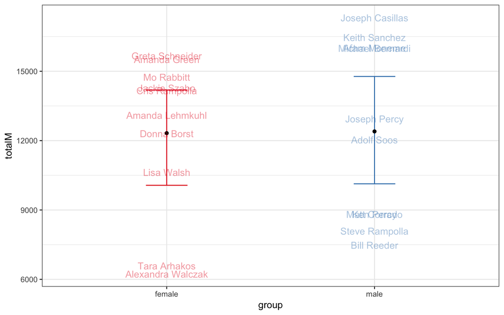

### 2.0.6 Plot of top 10 in each trial

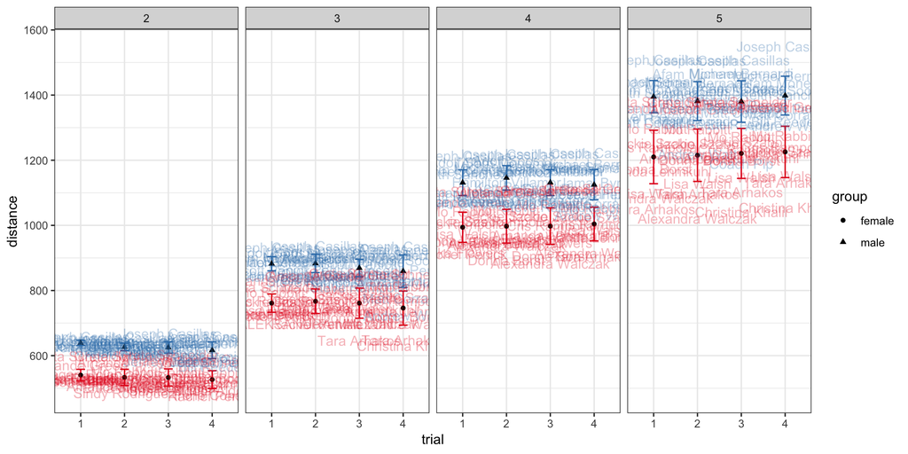

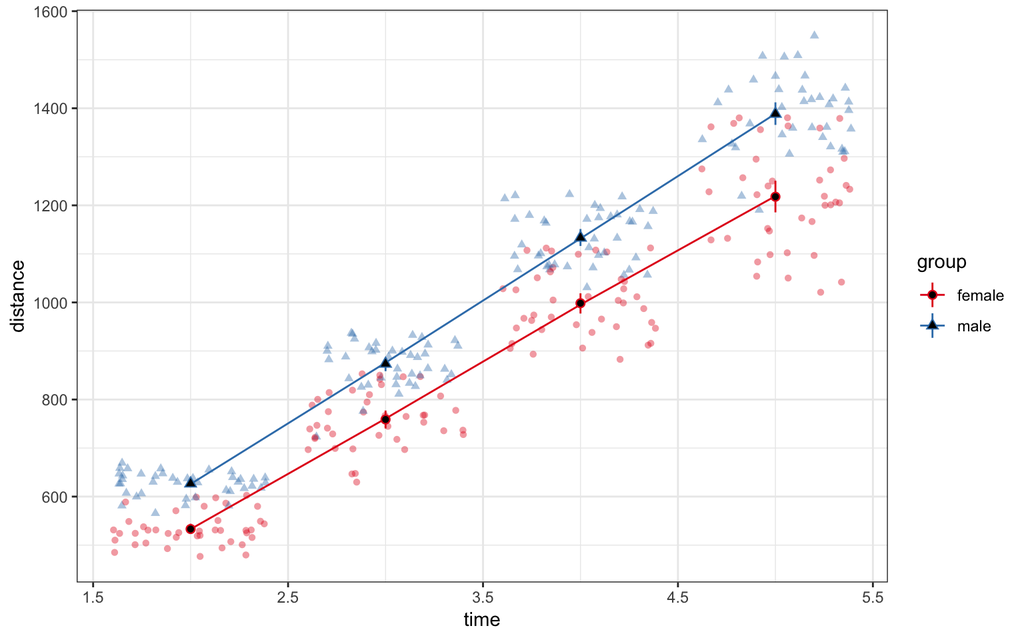

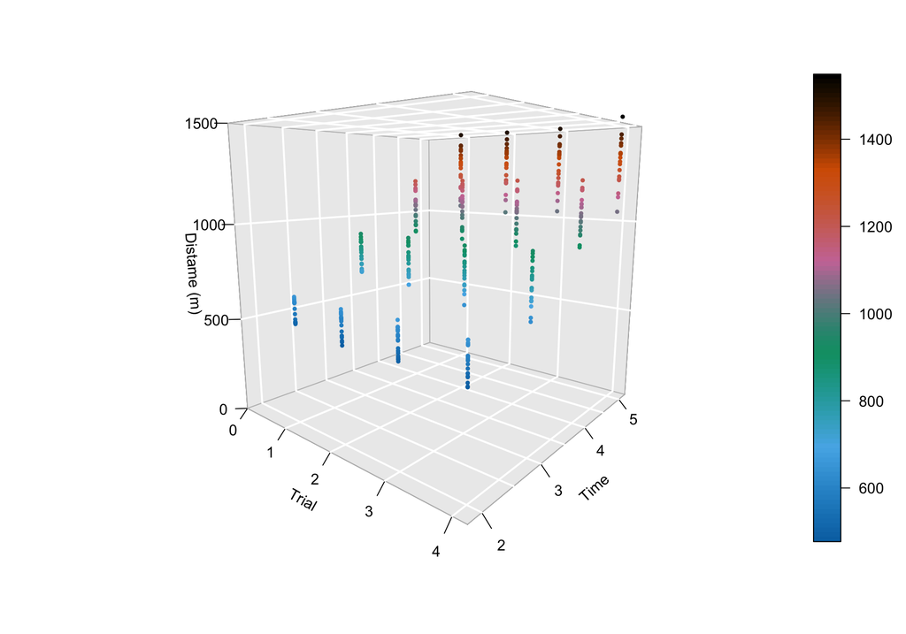